# HDAT9600 Team Based Learning Activity

TBLA 2. Linear model

Team A/The Outliers - Melvin Galera, Peter Nguyen, Melissa Weerappah, Kevin Qlintang

## Instructions

Using the `prostate` dataset (which comes with the `faraway` package for R) write some R code that

1. Performs a simple exploratory data analysis (EDA)
2. Fits a linear model, with the `lpsa` variable as the outcome (response), and the `lcavol` variable as the single predictor
3. Displays the R-squared and the residual standard error (RSE) for this model
4. Adds each of the variables `lweight`, `svi`, `lbph`, `age`, `lcp`, `pgg45` and `gleason` to the model, one-by-one
5. Displays the R-squared and RSE for each of these models
6. Creates two plots, one displaying the trend in R-squared as predictor variables are successively added to each model, and another plot showing the trend in RSE as predictor variables are successively added to each model
7. Finally, briefly describe what you observe in these plots

## Accessing the data

We can use the `data()` function from the `utils` package to load the data into the R environment, and the `head()` function to take a sneak peek.

```r
data(prostate, package = "faraway")
head(prostate)
```

```
##       lcavol lweight age      lbph svi      lcp gleason pgg45     lpsa
## 1 -0.5798185  2.7695  50 -1.386294   0 -1.38629       6     0 -0.43078
## 2 -0.9942523  3.3196  58 -1.386294   0 -1.38629       6     0 -0.16252
## 3 -0.5108256  2.6912  74 -1.386294   0 -1.38629       7    20 -0.16252
## 4 -1.2039728  3.2828  58 -1.386294   0 -1.38629       6     0 -0.16252
## 5  0.7514161  3.4324  62 -1.386294   0 -1.38629       6     0  0.37156
## 6 -1.0498221  3.2288  50 -1.386294   0 -1.38629       6     0  0.76547
```

Try entering `?faraway::prostate` at the console to get more information about this dataset.

## Submission

Work with your group to add your analysis to this file using appropriate Rmarkdown formatting and R code chunks. Add and commit your changes as you go. Once you are ready, push all your changes to submit. If necessary, check out the introductory tutorials on knitr and git.

## Solution

#### 1. Exploratory Data Analysis

- In this section, we performed a simple exploratory data analysis on the `prostate` dataset.
1. To see the summary statistics for each variable in the `prostate` dataset:

```r
str(prostate)
```

```
## 'data.frame':    97 obs. of  9 variables:
##  $ lcavol : num  -0.58 -0.994 -0.511 -1.204 0.751 ...
##  $ lweight: num  2.77 3.32 2.69 3.28 3.43 ...
##  $ age    : int  50 58 74 58 62 50 64 58 47 63 ...
##  $ lbph   : num  -1.39 -1.39 -1.39 -1.39 -1.39 ...
##  $ svi    : int  0 0 0 0 0 0 0 0 0 0 ...
##  $ lcp    : num  -1.39 -1.39 -1.39 -1.39 -1.39 ...
##  $ gleason: int  6 6 7 6 6 6 6 6 6 6 ...
##  $ pgg45  : int  0 0 20 0 0 0 0 0 0 0 ...
##  $ lpsa   : num  -0.431 -0.163 -0.163 -0.163 0.372 ...
```

```r
summary(prostate)
```

```
##      lcavol           lweight           age             lbph
##  Min.   :-1.3471   Min.   :2.375   Min.   :41.00   Min.   :-1.3863
##  1st Qu.: 0.5128   1st Qu.:3.376   1st Qu.:60.00   1st Qu.:-1.3863
##  Median : 1.4469   Median :3.623   Median :65.00   Median : 0.3001
##  Mean   : 1.3500   Mean   :3.653   Mean   :63.87   Mean   : 0.1004
##  3rd Qu.: 2.1270   3rd Qu.:3.878   3rd Qu.:68.00   3rd Qu.: 1.5581
##  Max.   : 3.8210   Max.   :6.108   Max.   :79.00   Max.   : 2.3263
##       svi              lcp             gleason          pgg45
##  Min.   :0.0000   Min.   :-1.3863   Min.   :6.000   Min.   :  0.00
##  1st Qu.:0.0000   1st Qu.:-1.3863   1st Qu.:6.000   1st Qu.:  0.00
##  Median :0.0000   Median :-0.7985   Median :7.000   Median : 15.00
##  Mean   :0.2165   Mean   :-0.1794   Mean   :6.753   Mean   : 24.38
##  3rd Qu.:0.0000   3rd Qu.: 1.1786   3rd Qu.:7.000   3rd Qu.: 40.00
##  Max.   :1.0000   Max.   : 2.9042   Max.   :9.000   Max.   :100.00
##       lpsa
##  Min.   :-0.4308
##  1st Qu.: 1.7317
##  Median : 2.5915
##  Mean   : 2.4784
##  3rd Qu.: 3.0564
##  Max.   : 5.5829
```

*Remarks:*

- The `prostate` data set contains 97 observations and 9 variables. All the variables are numeric.
- There are no missing values in the data set.

##### *Univariate Summaries*

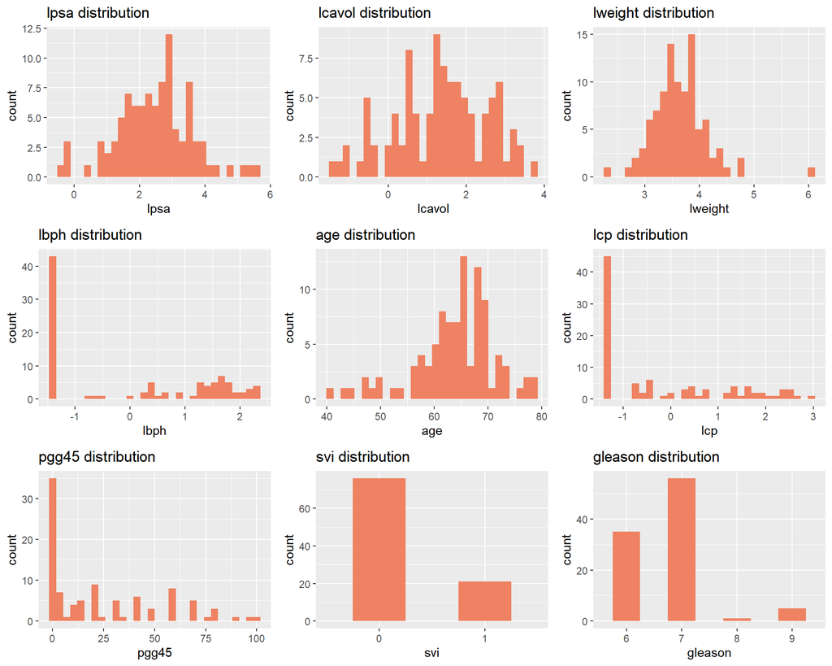

*Remarks:*

- The log of prostate specific antigen (`lpsa`) is normally distributed with mean of 2.48 and a range from -0.43 to 5.58.
- The log of cancer volume (`lcavol`) is normally distributed with mean of 1.35 and a range from -1.35 to 3.82.
- The log of prostate weight (`lweight`) is normally distributed with mean of 3.65 and a range from 2.38 to 6.11.
- The `age` is normally distributed with mean of 64 and a range from 41 to 79. Among the 97 observations, 76 have seminal vesicle invasion (`svi`) indicator of 0 and 21 have indicator of 1.
- Among the 97 observations, 35 have a `gleason` score of 6, 56 have a `gleason` score of 7, one has a `gleason` score of 8, and 5 have a `gleason` score of 9.
- The log of benign prostatic hyperplasia amount (`lbph`), the log of capsular penetration (`lcp`) and the percentage Gleasons scores 4 or 5 (`pgg45`) are not normally distributed.

##### *Bivariate Summaries*

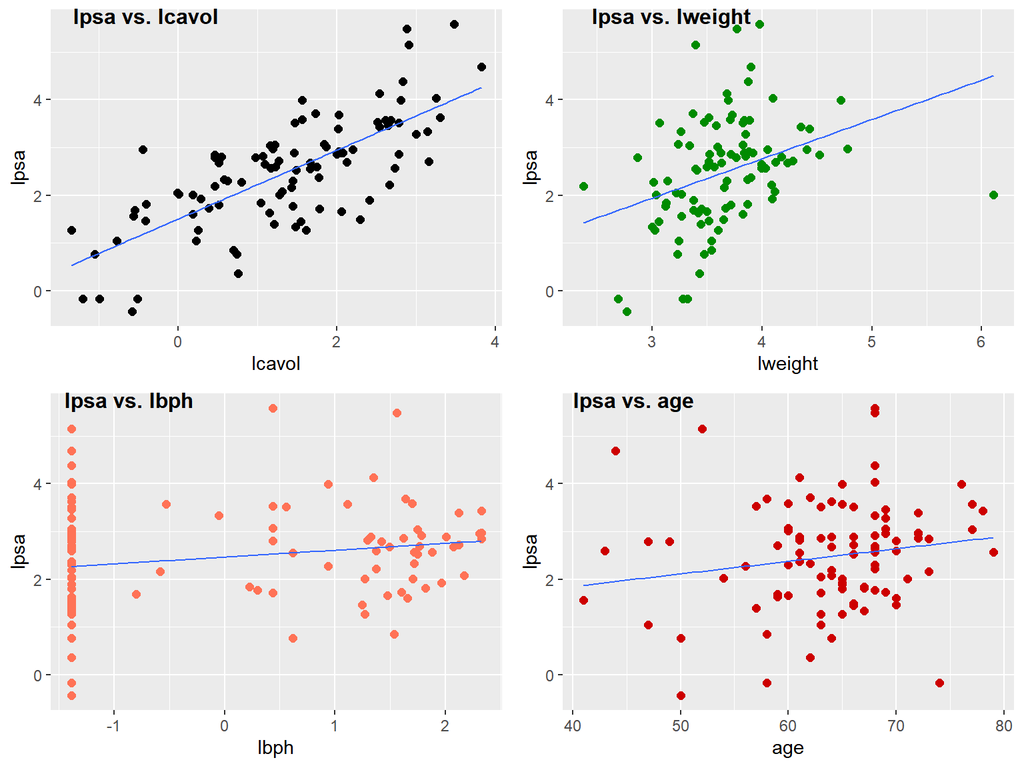

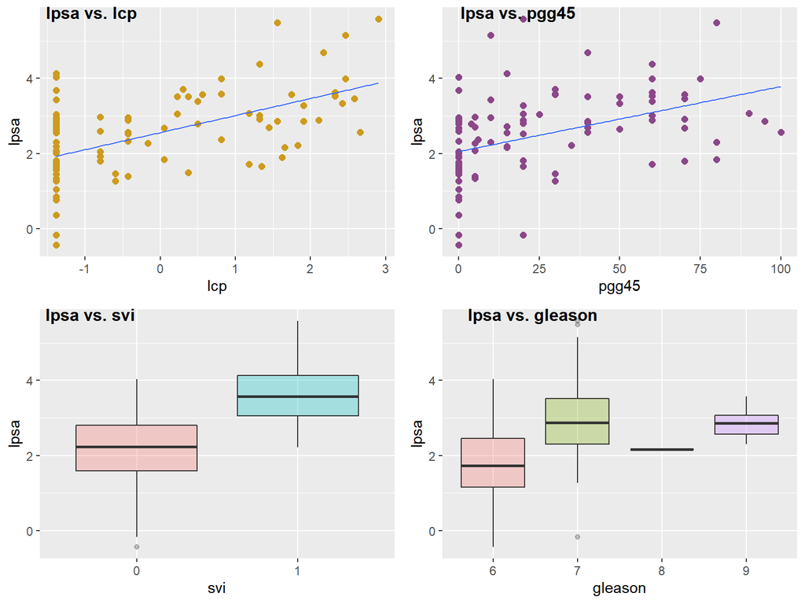

*Remarks:*

- There is a positive association between `lpsa` and `lcavol`. The correlation between the two variables was 0.73.
- There seems to be low positive association between `lpsa` and the other variables on the scatter point plots.
1. For `lpsa` and `lweight`- the correlation was 0.35.
2. For `lpsa` and `lbph` - the correlation was 0.18.
3. For `lpsa` and `age` - the correlation was 0.17.
4. For `lpsa` and `lcp` - the correlation was 0.55.
5. For `lpsa` and `pgg45` - the correlation was 0.42.
- There are more `svi` having a ‘1’ indicator at higher `lpsa` values compared to `svi` having an indicator of ‘0’.

#### 2. Fit a linear model, with the `lpsa` variable as the outcome (response), and the `lcavol` variable as the single predictor

- The linear model equation will be:

*lpsa = $\beta_{0}$ + $\beta_{1}$lcavol + $\epsilon$*

- The R code to fit the model via OLS can be written as:

```r
mod1 <- lm(lpsa ~ lcavol, data = prostate)
```

#### 3. Display the R-squared and the residual standard error (RSE) for this model

```r
mod1_R2 <- summary(mod1)$r.squared

mod1_RSE <- summary(mod1)$sigma
```

Linear Model (LM) with R-squared and Residual Standard Error (RSE) values

| Linear.Model | Predictor.Variable | R.Squared | RSE |
| --- | --- | --- | --- |
| LM 1 | lcavol | 0.5394319 | 0.7874994 |

#### 4. Add each of the variables `lweight`, `svi`, `lbph`, `age`, `lcp`, `pgg45` and `gleason` to the model, one-by-one.

- The linear model equations will be:
- *lpsa = $\beta_{0}$ + $\beta_{1}$lcavol + $\beta_{2}$lweight + $\epsilon$*
- *lpsa = $\beta_{0}$ + $\beta_{1}$lcavol + $\beta_{2}$lweight + $\beta_{3}$svi + $\epsilon$*
- *lpsa = $\beta_{0}$ + $\beta_{1}$lcavol + $\beta_{2}$lweight + $\beta_{3}$svi + $\beta_{4}$lbph + $\epsilon$*
- *lpsa = $\beta_{0}$ + $\beta_{1}$lcavol + $\beta_{2}$lweight + $\beta_{3}$svi + $\beta_{4}$lbph + $\beta_{5}$age + $\epsilon$*
- *lpsa = $\beta_{0}$ + $\beta_{1}$lcavol + $\beta_{2}$lweight + $\beta_{3}$svi + $\beta_{4}$lbph + $\beta_{5}$age + $\beta_{6}$lcp + $\epsilon$*
- *lpsa = $\beta_{0}$ + $\beta_{1}$lcavol + $\beta_{2}$lweight + $\beta_{3}$svi + $\beta_{4}$lbph + $\beta_{5}$age + $\beta_{6}$lcp + $\beta_{7}$pgg45 + $\epsilon$*
- *lpsa = $\beta_{0}$ + $\beta_{1}$lcavol + $\beta_{2}$lweight + $\beta_{3}$svi + $\beta_{4}$lbph + $\beta_{5}$age + $\beta_{6}$lcp + $\beta_{7}$pgg45 + $\beta_{8}$gleason + $\epsilon$*
- The R code to fit the models via OLS can be written as a list.

```r
#create a list of models
mod_list <- list(
    mod2 <- lm(lpsa ~ lcavol + lweight, data = prostate),
    mod3 <- lm(lpsa ~ lcavol + lweight + svi, data = prostate),
    mod4 <- lm(lpsa ~ lcavol + lweight + svi + lbph, data = prostate),
    mod5 <- lm(lpsa ~ lcavol + lweight + svi + lbph + age, data = prostate),
    mod6 <- lm(lpsa ~ lcavol + lweight + svi + lbph + age + lcp, data = prostate),
    mod7 <- lm(lpsa ~ lcavol + lweight + svi + lbph + age + lcp + pgg45, data = prostate),
    mod8 <- lm(lpsa ~ lcavol + lweight + svi + lbph + age + lcp + pgg45 + gleason, data = prostate)
   )
```

#### 5. Display the R-squared and RSE for each of these models

- We can create functions to obtain the adjusted R-squared values and the residual standard errors (RSE) from the `mod_list`. Note that we are extracting the adjusted R-squared because we are building linear regression on multiple variables.

```r
# create functions to extract adjusted R-squared and RSE values from the list
get_R2 <- function (x) {
  summary(x)$adj.r.squared
}

get_RSE <- function (x) {
  summary(x)$sigma
}

# use sapply function to get lists of R-squared and RSE values
r2_predictors <- sapply(mod_list, get_R2)
RSE_predictors <- sapply(mod_list, get_RSE)
```

Linear Models (LM) with their R-squared (adjusted) and Residual Standard Errors (RSE) values

| Linear.Model | Predictor.Variables | R.Squared | RSE |
| --- | --- | --- | --- |
| LM 2 | lcavol + lweight | 0.5771246 | 0.7506469 |
| LM 3 | lcavol + lweight + svi | 0.6143899 | 0.7168094 |
| LM 4 | lcavol + lweight + svi + lbph | 0.6208036 | 0.7108232 |
| LM 5 | lcavol + lweight + svi + lbph + age | 0.6245476 | 0.7073054 |
| LM 6 | lcavol + lweight + svi + lbph + age + lcp | 0.6214538 | 0.7102135 |
| LM 7 | lcavol + lweight + svi + lbph + age + lcp + pgg45 | 0.6272521 | 0.7047533 |
| LM 8 | lcavol + lweight + svi + lbph + age + lcp + pgg45 + gleason | 0.6271686 | 0.7048322 |

#### 6. Create two plots, one displaying the trend in R-squared as predictor variables are successively added to each model, and another plot showing the trend in RSE as predictor variables are successively added to each model

##### *Plot 1: R-squared vs Linear Model_s*

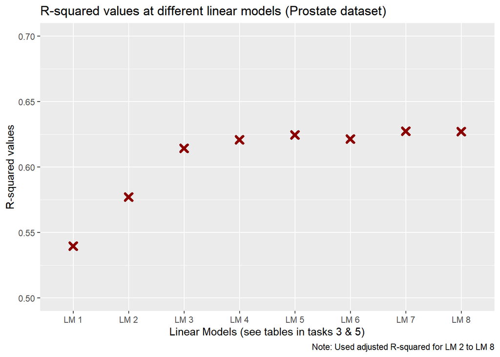

##### *Plot 2: RSE vs Linear Models*

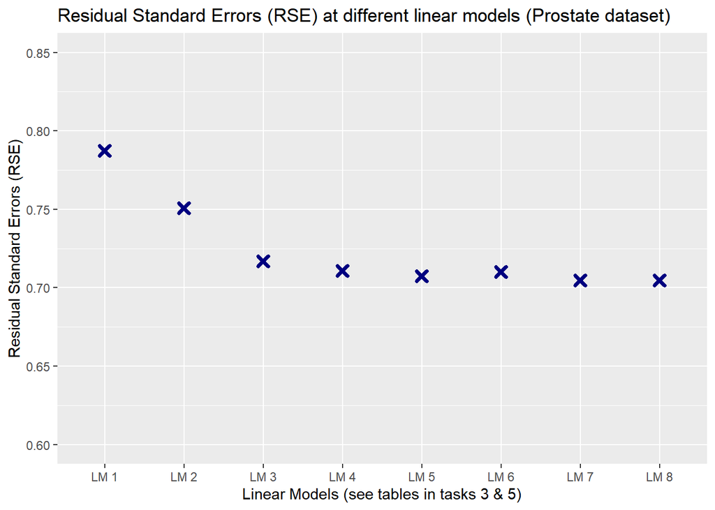

#### 7. Briefly describe observations in the plots

##### *Plot 1: R-squared vs Linear Model_s*

- With every addition of predictor variable to the model, the R-squared value increased up to a certain value before plateauing. After LM 3 (`lpsa ~ lcavol + lweight + svi`), there were very small changes in the R-squared values.

- On the other hand, the opposite trend was observed with RSE. With every addition of predictor variable to the model, the RSE value decreased to a certain value before plateauing. Also, after LM 3 (`lpsa ~ lcavol + lweight + svi`), very small changes in the RSE values observed.